# Building text analysis models using Quanteda

18 April 2018

## Introduction

## What is Quanteda?

**quanteda** is an R package for quantitative text analysis developed by a team based at the LSE.

- After 5 years of development, we released version 1.0 at London R meeting in January
- Used by leading political scientists in North America, Europe and Asia
- It is a stand-alone tool, but can be used to develop packages (e.g. **politeness**, **preText**, **phrasemachine**, **tidytext**, **stm**.
- Quanteda Initiative CIC was founded to support the text analysts community

## Why we need to develop text analysis models?

We want to discover *theoretically interesting* patterns in a corpus of texts from a social scientific point of view.

- The same technology as natural language processing (NLP) but for different goals
  - Replication of manual reading of text is not the goal
  - Computer scientific models are not always useful in social sciences
- Analytic methods vary from simple frequency analysis to neural network
  - Complex tools are not always the best choice
  - Training complex supervised model is usually expensive
  - Unsupervised models inexpensive but often atheoretical

## Challenges in developing text analysis models

We usually need a large corpus to find interesting patterns.

- Textual data is a typical high-dimensional data
  - In matrix representation (document-feature matrix or DFM) of texts
    - Each word is a variable (columns)
    - Each document is an observation (rows)
- Textual data is extremely sparse (99% or more)
  - Occurrences of important features are rare
  - Co-occurrences of interesting words are even rarer

## Example: non-rectangular structure

Tokenized texts are *non-rectangular*

```
## [1] "What is it?"               "That is a dolphine."
## [3] "No, it is a killer whale!"
```

```
## $text1
## [1] "What" "is"   "it"
##
## $text2
## [1] "That"     "is"       "a"        "dolphine"
##
## $text3
## [1] "No"     "it"     "is"     "a"      "killer" "whale"
```

## Example: data sparsity

Document-feature matrix is *sparse*

```
## [1] "What is it?"               "That is a dolphine."
## [3] "No, it is a killer whale!"
```

```
##        features
## docs    what is it that a dolphine no killer whale
##   text1    1  1  1    0 0        0  0      0     0
##   text2    0  1  0    1 1        1  0      0     0
##   text3    0  1  1    0 1        0  1      1     1
```

## We need special tools for large text data

We need *very efficient tools* to process large sparse matrices.

- **Base R** functions do not work well with non-rectangular/sparse data
  - `character` is not memory efficient when vectors are short
  - `data.frame` does not allow variables in different length (rectangular data)
  - `matrix` records both zero and non-zero values (dense matrix)

## Quanteda's design

## Quanteda's special objects: tokens

**quanteda** has `tokens` for tokenized texts.

```r
toks <- tokens(txt, remove_punct = TRUE)
print(toks)
```

```
## tokens from 3 documents.
## text1 :
## [1] "What" "is"   "it"
##
## text2 :
## [1] "That"     "is"       "a"        "dolphine"
##
## text3 :
## [1] "No"     "it"     "is"     "a"      "killer" "whale"
```

## Quanteda's special objects: dfm

**quanteda** has `dfm` for document-feature matrix.

```r
mt <- dfm(toks)
print(mt)
```

```
## Document-feature matrix of: 3 documents, 9 features (51.9% sparse).
## 3 x 9 sparse Matrix of class "dfm"
##        features
## docs    what is it that a dolphine no killer whale
##   text1    1  1  1    0 0        0  0      0     0
##   text2    0  1  0    1 1        1  0      0     0
##   text3    0  1  1    0 1        0  1      1     1
```

## Quanteda's functions: tokens_* and dfm_*

**quanteda** has many specialized methods for `tokens` and `dfm`.

- `tokens`
  - `tokens_select()` select tokens by patterns
  - `tokens_compound()` compound multiple tokens into single token
  - `tokens_lookup()` find dictionary words
- `dfm`
  - `dfm_select()` select features by patterns
  - `dfm_lookup()` find dictionary words
  - `dfm_group()` group multiple words into single document

Complete list of **quanteda**'s function is available at [documentation site](https://docs.quanteda.io/reference/).

## Unpacking tokens

`tokens` is an extension of `list` (S3).

```r
str(unclass(toks))
```

```
## List of 3
##  $ text1: int [1:3] 1 2 3
##  $ text2: int [1:4] 4 2 5 6
##  $ text3: int [1:6] 7 3 2 5 8 9
##  - attr(*, "types")= chr [1:9] "What" "is" "it" "That" ...
##  - attr(*, "padding")= logi FALSE
##  - attr(*, "what")= chr "word"
##  - attr(*, "ngrams")= int 1
##  - attr(*, "skip")= int 0
##  - attr(*, "concatenator")= chr "_"
##  - attr(*, "docvars")='data.frame':  3 obs. of  0 variables
```

## Unpacking dfm

`dfm` inherits `Matrix::dgCMatrix` (S4).

```r
mt@Dim
```

```
## [1] 3 9
```

```r
mt@Dimnames
```

```
## $docs
## [1] "text1" "text2" "text3"
##
## $features
## [1] "what"     "is"       "it"       "that"     "a"        "dolphine"
## [7] "no"       "killer"   "whale"
```

```r
mt@i
```

```
##  [1] 0 0 1 2 0 2 1 1 2 1 2 2 2
```

```r
mt@p
```

```
##  [1]  0  1  4  6  7  9 10 11 12 13
```

## Core APIs

## Creating tokens

```r
as.tokens(list(c("I", "like", "dogs"),
               c("He", "likes", "cats")))
```

```
## tokens from 2 documents.
## text1 :
## [1] "I"    "like" "dogs"
##
## text2 :
## [1] "He"    "likes" "cats"
```

```r
toks %>% as.list() %>% as.tokens() %>% class()
```

```
## [1] "tokens"
```

## Creating dfm

```r
as.dfm(matrix(c(1, 0, 2, 1), nrow = 2,
              dimnames = list(c("doc1", "doc2"),
                              c("dogs", "cats"))))
```

```
## Document-feature matrix of: 2 documents, 2 features (25% sparse).
## 2 x 2 sparse Matrix of class "dfm"
##       features
## docs   dogs cats
##   doc1    1    2
##   doc2    0    1
```

```r
as.dfm(rbind("doc" = c(3, 4)))
```

```
## Document-feature matrix of: 1 document, 2 features (0% sparse).
## 1 x 2 sparse Matrix of class "dfm"
##      features
## docs  feat1 feat2
##   doc     3     4
```

```r
mt %>% as.matrix() %>% as.dfm() %>% class()
```

```
## [1] "dfm"
## attr(,"package")
## [1] "quanteda"
```

## Convert dfm to Matrix

```r
as(mt, "dgCMatrix")
```

```
## 3 x 9 sparse Matrix of class "dgCMatrix"
##        features
## docs    what is it that a dolphine no killer whale
##   text1    1  1  1    . .        .  .      .     .
##   text2    .  1  .    1 1        1  .      .     .
##   text3    .  1  1    . 1        .  1      1     1
```

```r
as(mt, "dgTMatrix")
```

```
## 3 x 9 sparse Matrix of class "dgTMatrix"
##        features
## docs    what is it that a dolphine no killer whale
##   text1    1  1  1    . .        .  .      .     .
##   text2    .  1  .    1 1        1  .      .     .
##   text3    .  1  1    . 1        .  1      1     1
```

```r
dgmt <- as(mt, "dgTMatrix")
dgmt@i
```

```
##  [1] 0 0 1 2 0 2 1 1 2 1 2 2 2
```

```r
dgmt@j
```

```
##  [1] 0 1 1 1 2 2 3 4 4 5 6 7 8
```

```r
dgmt@x
```

```
##  [1] 1 1 1 1 1 1 1 1 1 1 1 1 1
```

## Converting pattern to type ID

```r
types(toks)
```

```
## [1] "What"     "is"       "it"       "That"     "a"        "dolphine"
## [7] "No"       "killer"   "whale"
```

```r
pattern2id("dolphine", types(toks), "fixed", TRUE)
```

```
## [[1]]
## [1] 6
```

```r
pattern2id(c("dolphine", "whale"), types(toks), "fixed", TRUE)
```

```
## [[1]]
## [1] 6
##
## [[2]]
## [1] 9
```

```r
pattern2id(phrase("killer whale"), types(toks), "fixed", TRUE)
```

```
## [[1]]
## [1] 8 9
```

## Converting regex to type ID

```r
pattern2id("^wha.*", types(toks), "regex", TRUE)
```

```
## [[1]]
## [1] 1
##
## [[2]]
## [1] 9
```

```r
pattern2fixed("^wha.*", types(toks), "regex", TRUE)
```

```
## [[1]]
## [1] "What"
##
## [[2]]
## [1] "whale"
```

## Converting glob to type ID

```r
pattern2id("wha*", types(toks), "glob", TRUE)
```

```
## [[1]]
## [1] 1
##
## [[2]]
## [1] 9
```

```r
pattern2fixed("wha*", types(toks), "glob", TRUE)
```

```
## [[1]]
## [1] "What"
##
## [[2]]
## [1] "whale"
```

## Using ID to subset ojbects

```r
featnames(mt)
```

```
## [1] "what"     "is"       "it"       "that"     "a"        "dolphine"
## [7] "no"       "killer"   "whale"
```

```r
id <- pattern2id("wha*", featnames(mt), "glob", TRUE)
mt[,unlist(id)]
```

```
## Document-feature matrix of: 3 documents, 2 features (66.7% sparse).
## 3 x 2 sparse Matrix of class "dfm"
##        features
## docs    what whale
##   text1    1     0
##   text2    0     0
##   text3    0     1
```

## Example 1: Newsmap

## Newsmap

**newsmap** is a semi-supervised model for geographical document classification originally created for [International Newsmap](http://newsmap.koheiw.net).

- **newsmap** identifies features associated with location using seed dictionary
  - **newsmap** extracts not only names of places but also names of people and organizations
  - Geographical classifier can be updated frequently without additional costs
- We have to perform dictionary analysis very accurately for **newsmap**
  - Place names are often comprised of multiple words (multi-word expressions)
  - Seed dictionaries are in multiple languages (English, German, Spanish, Japanese, Russian)

## Newsmap algorithm

**newsmap** is a semi-supervised multi-nomial naive Bayes classifier.

1. Search `tokens` for place names to assign country labels (weak supervision)
2. Compute association between geographical features and country labels
3. Predict geographical focus of documents

## Seed dictionary

```r
data_dictionary_newsmap_en[["AMERICA"]]["NORTH"]
```

```
## Dictionary object with 1 primary key entry and 2 nested levels.
## - [NORTH]:
##   - [BM]:
##     - bermuda, bermudan*
##   - [CA]:
##     - canada, canadian*, ottawa, toronto, quebec
##   - [GL]:
##     - greenland, greenlander*, nuuk
##   - [PM]:
##     - saint pierre and miquelon, st pierre and miquelon, saint pierrais, miquelonnais, saint pierre
##   - [US]:
##     - united states, us, american*, washington, new york
```

```r
data_dictionary_newsmap_de[["AMERICA"]]["NORTH"]
```

```
## Dictionary object with 1 primary key entry and 2 nested levels.
## - [NORTH]:
##   - [BM]:
##     - bermuda, bermudas
##   - [CA]:
##     - kanada, kanadas, kanadisch*, kanadier*, ottawa, toronto, quebec
##   - [GL]:
##     - grönland, grönlands, grönländisch*, nuuk
##   - [PM]:
##     - saint-pierre und miquelon, saint pierre
##   - [US]:
##     - vereinigte staaten von amerika, united states, vereinigte staaten, usa, us, amerikas, amerikanisch*, washington, new york
```

```r
data_dictionary_newsmap_ja[["AMERICA"]]["NORTH"]
```

```
## Dictionary object with 1 primary key entry and 2 nested levels.
## - [NORTH]:
##   - [BM]:
##     - バミューダ*
##   - [CA]:
##     - カナダ*, オタワ, トロント, ケベック
##   - [GL]:
##     - グリーンランド*, ヌーク
##   - [PM]:
##     - サンピエール・ミクロン島*, サンピエール, ミクロン
##   - [US]:
##     - 米国*, アメリカ*, ワシントン, ニューヨーク
```

## Pre-processing

```r
data <- readRDS("/home/kohei/Dropbox/Public/data_corpus_yahoonews.rds")
data$text <- paste0(data$head, ". ", data$body)
data$body <- NULL
corp_full <- corpus(data, text_field = 'text')
corp <- corpus_subset(corp_full, '2014-01-01' <= date & date <= '2014-12-31')
ndoc(corp)
```

```
## [1] 156980
```

```r
month <- c("January", "February", "March", "April", "May", "June",
           "July", "August", "September", "October", "November", "December")
day <- c("Sunday", "Monday", "Tuesday", "Wednesday", "Thursday", "Friday", "Saturday")
agency <- c("AP", "AFP", "Reuters")
toks <- tokens(corp) %>%
        tokens_remove(stopwords("en"), valuetype = "fixed", padding = TRUE) %>%
        tokens_remove(c(month, day, agency), valuetype = "fixed", padding = TRUE)
```

## Fit the Newsmap model

```r
label_mt <- dfm(tokens_lookup(toks, data_dictionary_newsmap_en, levels = 3))
feat_mt <- dfm(toks, tolower = FALSE) %>%
           dfm_select(selection = "keep", "^[A-Z][A-Za-z1-2]+", valuetype = "regex",
                      case_insensitive = FALSE) %>%
           dfm_trim(min_termfreq = 10)

newsmap <- textmodel_newsmap(feat_mt, label_mt)
summary(newsmap, n = 10)
```

```
## Classes:
##    bi, dj, er, et, ke, km, mg, mu, mw, mz ...
## Features:
##    French, Ivanovic, Safarova, PARIS, Former, Open, Ana, Lucie, Czech, Republic ...
## Documents:
##    text63, text68, text69, text73, text78, text79, text84, text85, text86, text92 ...
```

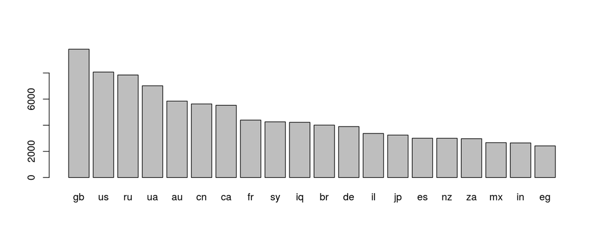

```r
tb <- table(predict(newsmap))
barplot(head(sort(tb, decreasing = TRUE), 20))
```

## Unpacking newsmap package

**newsmap** uses **quanteda** APIs in both estimation and prediction.

- `dfm_group()` groups documents based on labels
- `dfm_select()` makes features identical to the model
- `dfm_weight()` normalizes feature frequencies

## Example 2: LSS

## LSS package

**LSS** implements a semi-supervised document scaling model created based on **quanteda** to perform *theory-driven analysis at low costs*.

- **LSS** allow researchers to position documents on an arbitrary dimension
  - Full-supervised scaling models are often too expensive to train (e.g. Wordscore)
  - Unsupervised scaling models tend to produce atheoretical results (e.g. Wordfish)
- **LSS** requires large corpus to accurately estimate semantic relations
  - It has to handle extremely sparse matrix

## LSS algorithm

LSS (latent semantic scaling) is an application of LSA (latent semantic analysis) in document scaling

1. Construct a document-feature matrix from a large corpus (> 5000 documents)
2. Reduce the feature dimension to 300 using SVD (latent semantic space)
3. Weight terms based on their proximity to seed words in the semantic space
4. Predict positions of documents on a linear scale as weighted means of the terms

## Sentiment seed words

```r
seedwords('pos-neg')
```

```
##        good        nice   excellent    positive   fortunate     correct
##           1           1           1           1           1           1
##    superior         bad       nasty        poor    negative unfortunate
##           1          -1          -1          -1          -1          -1
##       wrong    inferior
##          -1          -1
```

## Other types of seed words

```r
# concern
c("concern*", "worr*", "anxi*")
```

```
## [1] "concern*" "worr*"    "anxi*"
```

```r
# dysfunction
c("dysfunct*", "paralysi*", "stalemate", "standstill", "gridlock", "deadlock")
```

```
## [1] "dysfunct*"  "paralysi*"  "stalemate"  "standstill" "gridlock"
## [6] "deadlock"
```

## Pre-processing

In LSS, documents are split into sentences to estimate semantic proximity based on immediate contexts of words. This makes document-feature matrix *extremely sparse*.

```r
corp <- readRDS("/home/kohei/Dropbox/Public/data_corpus_guardian2016-10k.rds")
sent_toks <-
    corp %>%
    corpus_reshape("sentences") %>%
    tokens(remove_punct = TRUE) %>%
    tokens_remove(stopwords("en")) %>%
    tokens_select("^[0-9a-zA-Z]+$", valuetype = "regex")
sent_mt <-
    sent_toks %>%
    dfm() %>%
    dfm_trim(min_termfreq = 5)
```

```r
ndoc(corp)
```

```
## [1] 10000
```

```r
ndoc(sent_mt)
```

```
## [1] 392697
```

```r
sparsity(sent_mt)
```

```
## [1] 0.9996725
```

## Fit LSS model

**lss** performs feature selection based on collocation to construct domain-specific sentiment models.

```r
eco <- head(char_keyness(sent_toks, 'econom*'), 500)
head(eco, 30)
```

```
##  [1] "growth"      "global"      "outlook"     "eurozone"    "slowdown"
##  [6] "slowing"     "uncertainty" "recession"   "markets"     "uk"
## [11] "zew"         "financial"   "gdp"         "markit"      "world"
## [16] "brexit"      "forecasts"   "china"       "rolling"     "jobs"
## [21] "prospects"   "quarter"     "davos"       "williamson"  "emerging"
## [26] "ihs"         "downturn"    "risks"       "tombs"       "recovery"
```

```r
lss <- textmodel_lss(sent_mt, seedwords('pos-neg'), features = eco, cache = TRUE)
```

```r
head(coef(lss), 30)
```

```
##        good    positive    emerging       china   expecting cooperation
##  0.05252521  0.03941849  0.03906230  0.03249657  0.03172653  0.03014628
##        drag        asia        prof   turbulent sustainable challenging
##  0.02910002  0.02873776  0.02849241  0.02824677  0.02765765  0.02682587
##     markets   investors      remain     beijing   prospects       stock
##  0.02644153  0.02637175  0.02629941  0.02572956  0.02570061  0.02538831
##      better   uncertain         hit     chinese   sentiment      mining
##  0.02479903  0.02358457  0.02302436  0.02291012  0.02269737  0.02230245
##      failed      threat      robust      argued consultancy      oxford
##  0.02213793  0.02196979  0.02192322  0.02192176  0.02190114  0.02176545
```

```r
tail(coef(lss), 30)
```

```
##       yellen        banks consequences       carney    inflation
##  -0.02971046  -0.03026749  -0.03048922  -0.03056076  -0.03126168
##    countries     downturn       macron     suggests     downbeat
##  -0.03194409  -0.03257441  -0.03258820  -0.03277442  -0.03309793
##         debt  assumptions         data policymakers    borrowing
##  -0.03386571  -0.03416451  -0.03524238  -0.03745570  -0.03815934
##   unbalanced       shrink unemployment          bad     pantheon
##  -0.03934074  -0.03944345  -0.03987688  -0.04047418  -0.04054125
##      cutting       shocks         hike        rates          mpc
##  -0.04082423  -0.04267978  -0.04370420  -0.04405703  -0.04427978
##       easing          rba         rate          cut     negative
##  -0.04577516  -0.04789902  -0.05417844  -0.05498620  -0.05697134
```

## Predicting economic sentiment

```r
doc_mt <- dfm(corp)
data_pred <- as.data.frame(predict(lss, newdata = doc_mt, density = TRUE))
data_pred$date <- docvars(doc_mt, 'date')
data_pred <- subset(data_pred, density > quantile(density, 0.25))

head(data_pred)
```

```
##                    fit    density       date
## text141269  0.74545003 0.02946955 2016-04-07
## text151432 -0.01325452 0.08580343 2016-05-10
## text169265 -0.24909294 0.05876393 2016-09-01
## text134827 -0.04752371 0.04449649 2016-03-08
## text133324  1.80075143 0.05355191 2016-03-03
## text132839  0.55650416 0.04322034 2016-02-22
```

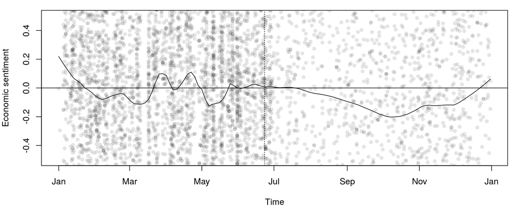

```r
par(mar = c(4, 4, 1, 1))
plot(data_pred$date, data_pred$fit, pch = 16, col = rgb(0, 0, 0, 0.1),
     ylim = c(-0.5, 0.5), ylab = "Economic sentiment", xlab = "Time")
lines(lowess(data_pred$date, data_pred$fit, f = 0.1), col = 1)
abline(h = 0, v = as.Date("2016-06-23"), lty = c(1, 3))
```

## Unpacking LSS package

LSS package is implemented using **RSpectra**'s SVD engine and **quanteda**'s APIs.

- `as.dfm()` converts a SVD-reduced matrix to a `dfm`
- `pattern2fixed()` converts seed words' glob to fixed patterns
- `textstat_simil()` computes term-term similarity between seed words and features
- `textstat_keyness()` performs chi-squre tests for collocations

## Conclusions

## For your own text models

**quanteda**'s APIs help you to quickly develop your own models.

- `pattern2id()` helps you to handle patterns, multi-word expressions and Unicode characters
- `tokens` and `dfm` objects can be created using `as.tokens()` and `as.dfm()`
- `tokens_*()` and `dfm_*()` are optimized for large textual data
- `textstat_*` are useful as packages' internal functions

You can also contribute to development of **quanteda**.

- If **quanteda** is missing important functions, file a feature request or pull request
- QI's Github account will host your **quanteda** extension packages (e.g. **quanteda.newsmap**) to give more publicity

## Additional materials

- Quanteda Documentation: https://docs.quanteda.io
- Quanteda Tutorials: https://tutorials.quanteda.io
- My personal website: https://koheiw.net